# Excercise 1

Membrane FilmeTec of thikness 1.3 μm was used for separation of sea water with concentration of salt 3.5 wt. %. The measurements were carried out at temperature 25°C. The following fluxes as the function of pressure on membrane was measured.

[output not shown]

Calculate:

1. Composition of permeate as function of pressure (mol/l, g/l).
2. Permeability of water and NaCl.
3. Rejection coefficient.
4. Osmotic pressure.

```matlab
a = 1
```

```
a =

     1
```

```matlab
%salt = s
%water = w
global C0_salt C0_water A B dP rho_water R T Vm
P = [41 , 48.7 , 55.4 , 61.6]; %[bar]
J_s = [2.9813 , 2.9592 , 2.898 2.9183]; %[g/m2.h]
J_w = [13.309 , 18.294 , 23.220 , 27.789]; %[L/m2.h]
MW_s = 58.44; %[g/mol]
MW_w = 18.01528; %[g/mol]
rho_s = 2160; %[g/L]
rho_w = 997; %[g/L]

% J_s and J_w to molar flux
J_s = J_s ./ MW_s;
J_w = J_w .* rho_w./MW_w;

% Retentate side
w0_s = 3.5/100; % mass frac
w0_w = 1 - w0_s; % mass frac
x0_s = (w0_s/MW_s)/((w0_s/MW_s)+(w0_w/MW_w)); % molar frac
x0_w = 1 - x0_s; % molar frac
rho_0 = 1/(w0_s/rho_s + w0_w/rho_w); %[g/L]
C0 = rho_0 / (x0_s*MW_s + x0_w*MW_w); %[mol/L]
C0_s = C0 * x0_s %[mol/L]
C0_w = C0 * x0_w %[mol/l]
```

```
C0_s =

    0.6086


C0_w =

   54.4307
```

```matlab
% permeate side
% Composition
xl_s = J_s./(J_s + J_w) % mole frac
xl_w = 1 - xl_s % mole frac
wl_s = (xl_s.*MW_s)./(xl_s.*MW_s + xl_w.*MW_w);
wl_w = 1 - wl_s;
rho_l = 1./(wl_s./rho_s + wl_w./rho_w); %[g/L]
Cl = rho_l ./ (xl_s.*MW_s + xl_w.*MW_w); %[mol/L]
Cl_s = Cl .* xl_s %[mol/L]
Cl_w = Cl .* xl_w %[mol/l]

% permeability
B = J_s./(C0_s - Cl_s)

Vm_w = MW_w*(1/rho_w); %[L/mol]
R = 8.314*10^-2; %[L.bar/mol.K]
T = 25 + 273; %[K]

dpi = log(Cl_w./C0_w)*(R*T)/Vm_w;
A = J_w./(P-dpi)

% Reject coefficient
R = (1 - Cl_s./C0_s)*100

% Osmosis pressure
dpi
```

```
xl_s =

   1.0e-04 *

    0.6926    0.5001    0.3859    0.3247


xl_w =

    0.9999    0.9999    1.0000    1.0000


Cl_s =

    0.0038    0.0028    0.0021    0.0018


Cl_w =

   55.3362   55.3378   55.3387   55.3392


B =

    0.0844    0.0836    0.0818    0.0823


A =

   40.0776   38.8819   39.2798   39.5321


R =

   99.3702   99.5452   99.6491   99.7047


dpi =

   22.6220   22.6615   22.6850   22.6975
```

# Exercise 2

From the experimental data measured at $25^0C$ on cellulose acetate membrane the water permeability constant was estimated. The calculated value at experimental conditions where solution of $0.13\;wt$% . NaCl in water have been used is $1\times10^{-5}\;g.cm^{-2}s^{-1}atm^{-1}$. The salt permeability constant defined as flux divided by the concentration differences have a value of $1\times 10^{-6} cm.s^{-1}$. Calculate rejection coefficient. Estimate the permeate composition when the pressure differences on membrane is 5 bar.

```matlab
% declare the variable
global C0_s C0_w
P = 5; %[bar]
A = 10^-5/18; %[g/cm2.s.atm] -> [mol/cm2.s.atm]
B = 10^-6; %[cm/s]
MW_s = 58.44; %[g/mol]
MW_w = 18; %[g/mol]
rho_s = 2160; %[g/L]
rho_w = 997; %[g/L]

% retentate side
w0_s = 0.13/100; % mass frac
w0_w = 1 - w0_s; % mass frac
x0_s = (w0_s/MW_s)/((w0_s/MW_s)+(w0_w/MW_w)); % molar frac
x0_w = 1 - x0_s; % molar frac
rho_0 = 1/(w0_s/rho_s + w0_w/rho_w); %[g/L]
C0 = rho_0 / (x0_s*MW_s + x0_w*MW_w); %[mol/L]
C0_s = C0 * x0_s /1000; %[mol/L] -> [mol/cm3]
C0_w = C0 * x0_w / 1000; %[mol/l] -> [mol/cm3]
```

```matlab
%%file ex2.m
function y = ex2(x)
global C0_s C0_w
% constant
P = 5; %[bar]
A = 10^-5/18; %[g/cm2.s.atm] -> [mol/cm2.s.atm]
B = 10^-6; %[cm/s]
MW_s = 58.44; %[g/mol]
MW_w = 18; %[g/mol]
rho_s = 2160; %[g/L]
rho_w = 997; %[g/L]
R = 8.314*10^-2; %[m3.bar/kmol.K]
T = 25 + 273; %[K]
Vm_w = MW_w*(1/rho_w); %[L/mol]


Js = x(1);
Jw = x(2);
% molar fraction -> molar concentration
xl_s = Js/(Js+Jw);
xl_w = 1 - xl_s;
wl_s = (xl_s*MW_s)/((xl_s*MW_s)+(xl_w*MW_w));
wl_w = 1 - wl_s;
rho_l = 1/(wl_s/rho_s + wl_w/rho_w);
Cl = rho_l/(xl_s*MW_s + xl_w*MW_w); %[kmol/m3]
Cl_s = Cl*xl_s/1000;
Cl_w = Cl*xl_w/1000;

Js_new = B*(C0_s - Cl_s);
pi = log(Cl_w/C0_w)*(R*T/Vm_w);
Jw_new = A*(P - pi);

y(1) = Js_new - Js;
y(2) = Jw_new - Jw;
end
```

```
Created file 'C:\Users\minht\MatlabJupyter\ex2.m'.
```

```matlab
J = fsolve(@ex2,[0.001 , 0.001]);
Js = J(1); % [mol/cm2s]
Jw = J(2); % [mol/cm2s]
% molar fraction -> molar concentration
xl_s = Js/(Js+Jw);
xl_w = 1 - xl_s;
wl_s = (xl_s*MW_s)/((xl_s*MW_s)+(xl_w*MW_w));
wl_w = 1 - wl_s;
rho_l = 1/(wl_s/rho_s + wl_w/rho_w);
Cl = rho_l/(xl_s*MW_s + xl_w*MW_w); %[kmol/m3]
Cl_s = Cl*xl_s/1000;
Cl_w = Cl*xl_w/1000;

% Composition
xl_s
xl_w

% Reject coefficient
R = (1 - Cl_s/C0_s)*100
```

```
Equation solved.

fsolve completed because the vector of function values is near zero
as measured by the value of the function tolerance, and
the problem appears regular as measured by the gradient.


xl_s =

   9.3027e-06


xl_w =

    1.0000


R =

   97.6784
```

# Excercise 3

A liquid containing dilute solute A at a concentration c1=0.030 kmol/m3 is flowing rapidly by a membrane of thickness L=3.0·10-5 m. The distribution (sorption) coefficient K’=1.5 and DAB=7.0·10-11 m2 /s in the membrane. The solute diffuses through the membrane and its concentration on the other side is c2=0.0050 kmol/m3. The mass transfer coefficient kc1 is large and can be considered as infinite and kc2=2.02·10 -5 m/s. a) Derive the equation to calculate the steady-state flux NA and make a sketch. b) Calculate the flux and the concentrations at the membrane interfaces.

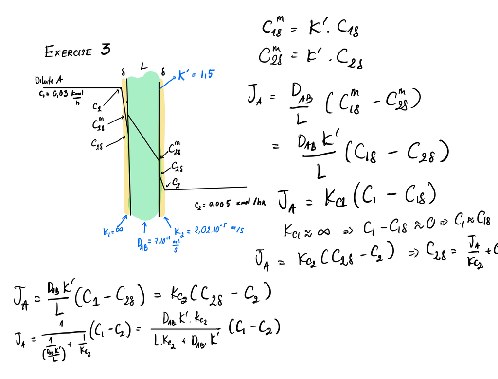

```matlab
% Excersíse 3

D = 7*10^-11; %[m2/s]
K = 1.5;
L = 3*10^-5; %[m]
kc2 = 2.02*10^-5; %[m/s]
C1 = 0.03; %[kmol/m3]
C2 = 0.005; %[kmol/m3]

kov = D*K*kc2/(L*kc2 + D*K); %[m/s]

JA = kov*(C1 - C2) %[kmol/m2s]

% Concentration at interface
C1m = K*C1 %[kmol/m3]
C2bl = JA/kc2 + C2 %[kmol/m3]
C2m = K*C2bl %[kmol/m3]
```

```
JA =

   7.4578e-08


C1m =

    0.0450


C2bl =

    0.0087


C2m =

    0.0130
```

# Excercise 4

Experiments at 25oC were performed to determine the permeabilities of a cellulose acetate membrane. The laboratory test section has a membrane area A=2·10-3 m2. The inlet feed solution concentration of NaCl is c1=10 g NaCl/L solution (ρ1=1004 kg sol./m3). The water recovery is assumed low so that the concentration c1 in the entering feed solution flowing past the membrane and the concentration of the reject solution are equal. The product solution contains c2=0.39 g NaCl/L sol. (ρ2 =997 kg sol./m3) and its flow rate is 1.92·10-8 m3 sol./s. A pressure differential of 5514 kPa (54.42 atm) is used. Calculate the permeability constants and the solute rejection R.

$J_m = J_{NaCl} + J_{H2O}$

$J_{NaCl} = B\times(C_1 - C_2)$

$J_{H2O} = A\times(\Delta P - \Delta \pi)$

```matlab
% Excercise 4
A = 2*10^-3; %[m2]
F = 1.92*10^-8; %[m3_sol/s]
J = F/A; %[m3_sol/m2.s]
MW_s = 58.44; %[kg/kmol]
MW_w = 18; %[kg/kmol]
rho_s = 2160; %[kg/m3]

C0_s = 10/58.44*1000 % Salt [mol/m3]
Cl_s = 0.39/58.44*1000 % Salt [mol/m3]

Js = J*Cl_s %[mol_salt/m2.s]
rho_0 = 1004; % Solution [kg/m3] at retentate
rho_l = 997; % Solution [kg/m3] at permeance
P = 54.42; % [atm]

% Rejection coefficient
R = (1 - Cl_s/C0_s)*100

% Permeability constant
B = Js./(C0_s - Cl_s)
```

```
C0_s =

  171.1157


Cl_s =

    6.6735


Js =

   6.4066e-05


R =

   96.1000


B =

   3.8959e-07
```

[output not shown]

```matlab
R = 8.314*10^-2; %[m3.bar/kmol.K]
T = 25 + 273; %[K]
Vm_s = MW_s*(1/rho_s) %[m3/kmol]
pi = (C0_s - Cl_s)/1000*R*T
Jm_w = J*rho_l - Js/1000*MW_s; %[kg/m2.s]
Jw = Jm_w / MW_w * 1000 %[mol/m2.s]
A = Jw/(P - pi)
```

```
Vm_s =

    0.0271


pi =

    4.0742


Jw =

    0.5315


A =

    0.0106
```

```matlab
log(0.39/10)*R*T/Vm_s
```

```
ans =

  -2.9708e+03
```

# Exercise 5

A liquid containing dilute solute A at concentration c1=0.03 kmol/m3 is flowing rapidly pat a membrane of thickness 30 μm. The distribution coefficient K A= 1.5 and diffusion coefficient in the membrane D AB=7x10-11 m2/s. The solute diffuses trough the membrane, ad its concentration on the other side is 0.005 kmol/m3. The mass transfer coefficient on the feed side of membrane is large and can be considered as infinite, and the mass transfer coefficient and the permeate side of membrane is 2.02x10-5 m/s. A) Derivethe equation to calculate the steady-state flux J A and make a sketch. B) Calculate flux and the concentrations at membrane interface.

# Exercise 6

A membrane is to be used to separate a gaseous mixture A and B whose feed flow rate is 10 L(STP)/s and feed composition of A is xA =0.5 mole fraction. The desired composition of retentate is x AR= 0.25 mole fraction.The membrane thickness is 25.4 μm. The pressure on the feed side is 80 cm Hg and on the permeate side 20 cm Hg. The permeabilities are P’ A =50x10-10 cm3(STP) cm/(s cm2 cm Hg) P’A =5x10-10. Calculate the permeate composition , membrane area and stage cut.

```matlab
% Excercise 6
F_F = 10*1e3; %[cm3(STP)/s]
xA_F = 0.5;
t = 25.4*1e-4; %[cm]
Pi_A = 50*10^-10;
Pi_B = 5*10^-10;
xA_R = 0.25;
P_R = 80;
P_P = 20;
a = Pi_A/Pi_B;
g = P_R/P_P;
ex6 = @(x)((x/(1-x))-a*((g*xA_R - x)/(g*(1-xA_R)-(1-x))));
xA_P = fzero(ex6,[0,0.99])
F_P = F_F*(xA_F - xA_R)/(xA_P-xA_R)
JA = Pi_A/t*(P_R*xA_R - P_P*xA_P)
Am = F_P*xA_P/JA*0.0001 % m2
phi = F_P / F_F
```

```
xA_P =

    0.6036


F_P =

   7.0705e+03


JA =

   1.5607e-05


Am =

   2.7344e+04


phi =

    0.7071
```

# Exercise 7

The organic mixture of 20 wt. % solution of n-decane in methyl-ethyl-ketone (MEK) is separated on the membrane. The ratio of permeabilities of MEK and decane is 10. The permeability of MEK is 4.8x10 -11 m2 s-1 and thickness of top membrane separation layer is 5 μm. Calculate the dependencies of n-decane rejection and MEK and n-decane fluxes as the function of applied pressure. The densities of pure MEK and n-decane at 20 °C are 804.9 and 703 kg/m3, respectively. The molar weights of MEK is 72.11 g/mol and n-decane 142.28 g/mol.

```matlab
% decane = A
% MKE = B
global Pi_B Pi_A t rho_A rho_B MW_A MW_B C0_A C0_B dP Vm_A Vm_B pi
Pi_B = 4.8*10^-11; %[m2/s]
Pi_A = Pi_B/10;
t = 5*1e-6; %[m]
rho_A = 703; %[kg/m3] pure
rho_B = 804.9; %[kg/m3] pure
MW_A = 142.28; %[kg/kmol]
MW_B = 72.11; %[kg/kmol]
dP = linspace(5,170,20); %[bar]
Vm_A = MW_A/rho_A %[m3/kmol]
Vm_B = MW_B/rho_B %[m3/kmol]
% retentate side
wA_0 = 0.2;
wB_0 = 1 - wA_0;
rho_0 = 1/(wA_0/rho_A + wB_0/rho_B)
C0_A = rho_0*wA_0
C0_B = rho_0*wB_0
pi = 10;
```

```
Vm_A =

    0.2024


Vm_B =

    0.0896


rho_0 =

  782.2233


C0_A =

  156.4447


C0_B =

  625.7787
```

```matlab
%%file ex10.m
function y = ex10(x)
global Pi_B Pi_A t rho_A rho_B MW_A MW_B C0_A C0_B dP Vm_A Vm_B pi
R = 8.314*10^-2; %[m3.bar/kmol.K]
T = 20 + 273; %[K]
wA_l = x;
wB_l = 1-wA_l;
rho_l = 1/(wA_l/rho_A + wB_l/rho_B);% mass conc total
Cl_A = rho_l*wA_l;
Cl_B = rho_l*wB_l;
JA = Pi_A/t*(C0_A - Cl_A*exp(-Vm_A/(R*T)*pi));
JB = Pi_B/t*(C0_B - Cl_B*exp(-Vm_B/(R*T)*pi));
a = exp(-Vm_A/(R*T)*pi);
wA_l_new = JA/(JA + JB);
y = wA_l - wA_l_new;
end
```

```
Created file 'C:\Users\minht\MatlabJupyter\ex10.m'.
```

```matlab
Ws_A = [];
for i = 1:length(dP)
pi = dP(i);
wA_l = fsolve(@ex10,0.2);
Ws_A = [Ws_A,wA_l];
end
```

[output not shown]

[output cut: 83 more lines]

[output not shown]

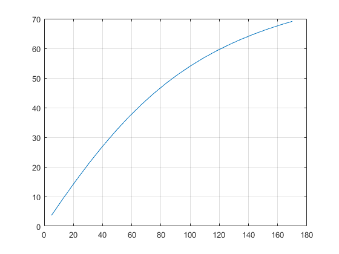

```matlab
Ws_A;
Ws_B = 1 - Ws_A;
Rho_l = 1./(Ws_A./rho_A + Ws_B/rho_B);
Cs_A = Ws_A.*Rho_l;
Rej = (1 - Cs_A./C0_A)* 100;
plot(dP,Rej)
grid('on')
```